# NFL Play Prediction Modeling

The NFL is an extremely competitive league where every play has incredibly high stakes. In a league where there are only 16 regular season games and teams average about 70 offensive plays per game, every play is incredibly important. This means that information on your opponent is key. The greatest players are able to disect the opposing team and know exactly what they are about to do. Greats like Peyton Manning and Luke Kuechly have ridden this ability to the top of their respective positions and make their teams better for it.

This means that any additional information you can get about what your opponent is about to do will make your team that much more deadly. So in this notebook, I'll be building a model that uses information about the game state to predict whether the offense will be running or passing the ball on their next play.

To do this, I've scraped play data from [Pro Football Reference](https://www.pro-football-reference.com/). This data contains information like Down, Distance, and time left in the game in addition to what type of play was ran. I've limited it effort to plays ran in the 2014 - 2018 seasons and only plays on 1st-3rd down.

First we need to load our dependencies and data.

```python
import numpy as np
import pandas as pd
import datetime
import re
import itertools
import matplotlib.pyplot as plt
import seaborn as sns
from sklearn.linear_model import LogisticRegression
from sklearn.preprocessing import StandardScaler
from sklearn.model_selection import train_test_split, GridSearchCV
from collections import Counter
from sklearn.metrics import confusion_matrix, accuracy_score
from sklearn.tree import DecisionTreeClassifier, plot_tree
from matplotlib.pylab import rcParams
from sklearn.ensemble import RandomForestClassifier
from sklearn.metrics import roc_curve, auc
from matplotlib.legend_handler import HandlerLine2D
from xgboost import XGBClassifier, cv


def plot_confusion_matrix(cm, classes,
                          normalize=False,
                          title='Confusion matrix',
                          cmap=plt.cm.Blues):
    """
    This function prints and plots the confusion matrix.
    Normalization can be applied by setting `normalize=True`.
    """
    if normalize:
        cm = cm.astype('float') / cm.sum(axis=1)[:, np.newaxis]
        print("Normalized confusion matrix")
    else:
        print('Confusion matrix, without normalization')

    #print(cm)

    plt.imshow(cm, interpolation='nearest', cmap=cmap)
    plt.title(title)
    plt.colorbar()
    tick_marks = np.arange(len(classes))
    plt.xticks(tick_marks, classes, rotation=45)
    plt.yticks(tick_marks, classes)

    fmt = '.2f' if normalize else 'd'
    thresh = cm.max() / 2.
    for i, j in itertools.product(range(cm.shape[0]), range(cm.shape[1])):
        plt.text(j, i, format(cm[i, j], fmt),
                 horizontalalignment="center",
                 color="white" if cm[i, j] > thresh else "black")

    plt.ylabel('True label')
    plt.xlabel('Predicted label')
    plt.tight_layout()


plays = pd.read_csv('Data/PlayData.csv', parse_dates=['Date']).iloc[:,1:]
```

Lets take a look out our data:

```python
print(f'Plays: {plays.shape[0]}\nColumns: {plays.shape[1]}')
plays.sample(frac=1).head()
```

```
Plays: 82057
Columns: 17
```

|  | Date | Tm | Opp | Quarter | Time | Down | ToGo | Location | Score | Detail | Yds | EPB | EPA | Diff | play | playlocation | HomeAway |
| --- | --- | --- | --- | --- | --- | --- | --- | --- | --- | --- | --- | --- | --- | --- | --- | --- | --- |
| 41153 | 2018-12-23 | Panthers | Falcons | 2 | 1:43 | 3 | 1 | ATL 10 | 10-10 | Christian McCaffrey middle for 5 yards (tackl... | 5 | 4.69 | 6.06 | 1.37 | Rush | M | H |
| 48255 | 2015-11-22 | Chiefs | Chargers | 2 | 8:42 | 3 | 8 | SDG 48 | 6-3 | Alex Smith pass complete short left to Jerem... | 10 | 1.29 | 3.05 | 1.76 | Pass | SL | R |
| 39149 | 2018-12-02 | Giants | Bears | 3 | 15:00 | 1 | 10 | NYG 25 | 10-14 | Saquon Barkley right guard for 14 yards (tack... | 14 | 0.61 | 1.53 | 0.92 | Rush | RG | H |
| 76732 | 2018-10-28 | Steelers | Browns | 3 | 1:15 | 1 | 10 | PIT 45 | 23-12 | Ben Roethlisberger pass complete short right ... | 14 | 1.93 | 2.85 | 0.92 | Pass | SR | H |
| 34353 | 2018-10-07 | Chiefs | Jaguars | 2 | 4:15 | 1 | 10 | KAN 49 | 10-0 | Kareem Hunt right end for 2 yards (tackle by ... | 2 | 2.19 | 1.92 | -0.27 | Rush | RE | H |

## Data Munging

The first thing we need to do is perform some alterations and calculations to get the model inputs I want.

There is an issue in the data where if a play results in a touchdown, the score is already updated. We want the pre-touchdown score. So if the word "Touchdown" is in the Detail column, we will subtract 6 from the offensive score

Now we need to calculate field position. To keep things positive, we will use the distance to touchdown. Thus the further down the field an offense is the lower that value will be.

The last calculation I want is the amount of time left in the game. Our data currently contains quarter and minute information so we will need to do some conversions.

```python
plays['Location_team_abbrev'] = plays.Location.str.slice(start = 0 , stop = 3)
plays['Yard_line'] = plays.Location.str.slice(start = -2 ).astype(int)
plays['year'] = pd.DatetimeIndex(plays.Date).year

# Capture offensive and defensive scores in separate columns
scores = plays['Score'].str.split('-', expand = True)
plays['Off_score'] = scores[0].astype(int)
plays['Def_score'] = scores[1].astype(int)

# Edit offensive score to account for score prior to touchdowns
plays['Off_score'] = pd.np.where(plays.Detail.str.lower().str.contains("touchdown"), plays.Off_score -6, plays.Off_score)

# Calculate score differential
plays['Score_diff'] = plays.Off_score - plays.Def_score

# Calculate Distance to Goal line
team_abbrv_dict = plays[['Tm', 'Location_team_abbrev']].groupby(['Tm', 'Location_team_abbrev']).size().reset_index().sort_values(by = 0, ascending = False)[:32][['Tm', 'Location_team_abbrev']]
team_abbrv_dict.columns = ['Tm', 'Off_team_abbrev']

plays = plays.merge(team_abbrv_dict, on = 'Tm')
plays['Distance_to_goal'] = pd.np.where(plays.Yard_line == 50, 50,
           pd.np.where(plays.Location_team_abbrev == plays.Off_team_abbrev, (50 - plays.Yard_line) + 50, plays.Yard_line))

# Calculate time left in game
times = plays.Time.str.split(':', expand = True)
plays['Time_dec'] = times[0].astype(float) + (times[1].astype(float)/60)
plays['Time_left_in_game'] = pd.np.where(plays.Quarter == 1, 45 + plays['Time_dec'],
           pd.np.where(plays.Quarter == 2, 30 + plays['Time_dec'],
                      pd.np.where(plays.Quarter == 3, 15 + plays['Time_dec'], plays['Time_dec'])))

# HomeAway captures neutral site games as N.  For this effort I'll calculate neutral site games as away games
plays['HomeAway'] = pd.np.where(plays.HomeAway == 'N', 'R', plays.HomeAway)
# I'll also binarize HomeAway
plays['HomeGame'] = pd.np.where(plays.HomeAway == 'H', 1, 0)
```

## Target analysis

The playlocation column tells us what type and where the play was ran. It will eventually be our target. Lets make it a little more readable and store in a new variable.

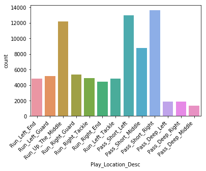

```python
playloc = {'DR':'Pass_Deep_Right',
          'DM':'Pass_Deep_Middle',
          'DL': 'Pass_Deep_Left',
          'SR': 'Pass_Short_Right',
          'SM': 'Pass_Short_Middle',
          'SL': 'Pass_Short_Left',
          'LE': 'Run_Left_End',
          'LT': 'Run_Left_Tackle',
          'LG': 'Run_Left_Guard',
          'M': 'Run_Up_The_Middle',
          'RG': 'Run_Right_Guard',
          'RT': 'Run_Right_Tackle',
          'RE': 'Run_Right_End'}
plays['Play_Location_Desc'] = plays.playlocation.map(playloc)
sns.countplot(plays.Play_Location_Desc)
plt.xticks(rotation=45, ha='right')
plt.show()
```

Looks like, more often than not, a team is going to either throw it short, or run it up the middle. A run anywhere but up the middle has roughly the same liklihood as one another but teams only rarely throw it deep. Pro Football Reference defines a deep pass attempt as any pass with 15 or more attempted air yards. For simpliciy sake, in this effort, I will only be classifying between a run or a pass attempt. In later iterations I may take this further and attempt to predict a more specific play type.

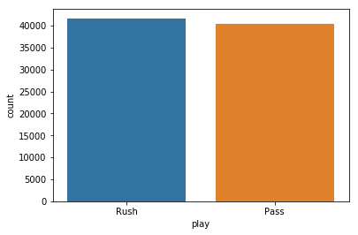

```python
sns.countplot(plays.play)
plt.show()
```

When broken down to simply run vs pass, the attempts are almost identical. This means that a blind guess would result in being right about 50% of the time.

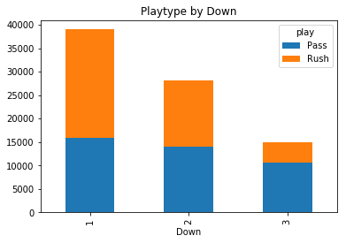

```python
plays.groupby(['Down', 'play']).size().unstack().plot(kind='bar', stacked=True)
plt.title('Playtype by Down')
plt.show()
```

If we break down run vs. pass plays by down, 1st down is weighted slightly to Rushing, 2nd Down is split pretty evenly, and 3rd down is weighted heavily to Passing

```python
counts = Counter(pd.np.where(plays.play == 'Pass', 1, 0))
Naive_acc = counts[0]/(counts[0] + counts[1])
print(f'If we assume every play is a run, we will be right {round(Naive_acc * 100,1)}% of the time')
```

```
If we assume every play is a run, we will be right 50.8% of the time
```

So 50.8% accuracy is our naive baseline. We will compare models to this value moving forward.

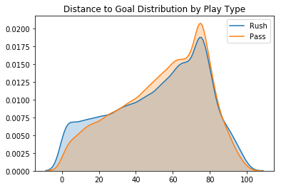

```python
sns.kdeplot(plays.Distance_to_goal[plays.play == 'Rush'], shade = True, label = 'Rush')
sns.kdeplot(plays.Distance_to_goal[plays.play == 'Pass'], shade = True, label = 'Pass')
plt.title('Distance to Goal Distribution by Play Type')
plt.show()
```

Looks like teams tend to rush a little more when they get into the red zone but otherwise the distribution is very similar.

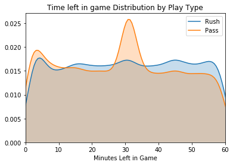

```python
sns.kdeplot(plays.Time_left_in_game[plays.play == 'Rush'], shade = True, label = 'Rush')
sns.kdeplot(plays.Time_left_in_game[plays.play == 'Pass'], shade = True, label = 'Pass')
plt.xlim(0,60)
plt.xlabel('Minutes Left in Game')
plt.title('Time left in game Distribution by Play Type')
plt.show()
```

This is interesting. We see spikes near the 30 minute and 0 minute left marks. This indicates the 2 - minute offense is real. Since teams want to score if possible they are much more careful about letting time run off the clock which results in the play density going up. Seeing increased rushes early in the game goes along with the idea of "establishing the run" early in the game.

## Modelling

Now we can begin creating models, I'll start off with a logistic regression as a baseline. These models are easy to interpret and easy to make so they make a great starting point. Unfortunately they tend to not be very accurate.

### Logistic Regression

```python
modcolumns = ['Down', 'ToGo', 'HomeGame', 'Score_diff', 'Distance_to_goal', 'Time_left_in_game']
X = plays[modcolumns]
y = pd.np.where(plays.play == 'Pass', 1, 0)

X_train, X_test, y_train, y_test = train_test_split(X, y, test_size = .33, random_state = 51)

# Logistic Regression requires scaled inputs so we will use sklearns StandardScaler to do the lifting for us
ss = StandardScaler()
X_train_scaled = ss.fit_transform(X_train)
X_test_scaled = ss.transform(X_test)
X_train_scaled = pd.DataFrame(X_train_scaled, columns = X.columns)
X_test_scaled = pd.DataFrame(X_test_scaled, columns = X.columns)

logreg = LogisticRegression()
logreg.fit(X_train_scaled, y_train)
train_preds = logreg.predict(X_train_scaled)
train_acc = accuracy_score(y_train, train_preds)
y_pred = logreg.predict(X_test_scaled)
test_acc = accuracy_score(y_test, y_pred)
cm = confusion_matrix(y_test, y_pred)
print(f'In-Sample Accuracy: {train_acc} Test Accuracy: {test_acc}')
```

```
In-Sample Accuracy: 0.6436028957037361 Test Accuracy: 0.6366926400531777
```

So with a simple logistic regression, we are already predicting the correct response 63.7% of the time! Thinking back to our naive accuracy, we are already 12.9 percentage points better! Lets check out what factors lead to each decision.

```python
coefs = logreg.coef_
coefs = (np.exp(coefs) - 1) * 100
coefs = pd.DataFrame(coefs, columns = X_train.columns)
print('Coefficients converted to Percent Change in Odds')
coefs
```

```
Coefficients converted to Percent Change in Odds
```

|  | Down | ToGo | HomeGame | Score_diff | Distance_to_goal | Time_left_in_game |
| --- | --- | --- | --- | --- | --- | --- |
| 0 | 85.65859 | 55.136517 | 4.122466 | -30.45783 | 2.392535 | -8.458824 |

This is all great but can we make this model a little more accurate? Well I suspect there are non-linear relationships in this data so lets try a decision tree.

### Decision Tree

Decision trees are excellent at picking up on the subtle interactions between variables and are very easy to read so they are always an interesting model type.

```python
tree = DecisionTreeClassifier(max_depth = 10)
tree.fit(X_train, y_train)
train_preds = tree.predict(X_train)
train_acc = accuracy_score(y_train, train_preds)
y_pred = tree.predict(X_test)
test_acc = accuracy_score(y_test, y_pred)
print(f'Accuracy: {round(test_acc * 100 , 2)}%')
```

```
Accuracy: 68.44%
```

So now we see an increased accuracy up to 68%! Lets plot the first couple splits of this tree.

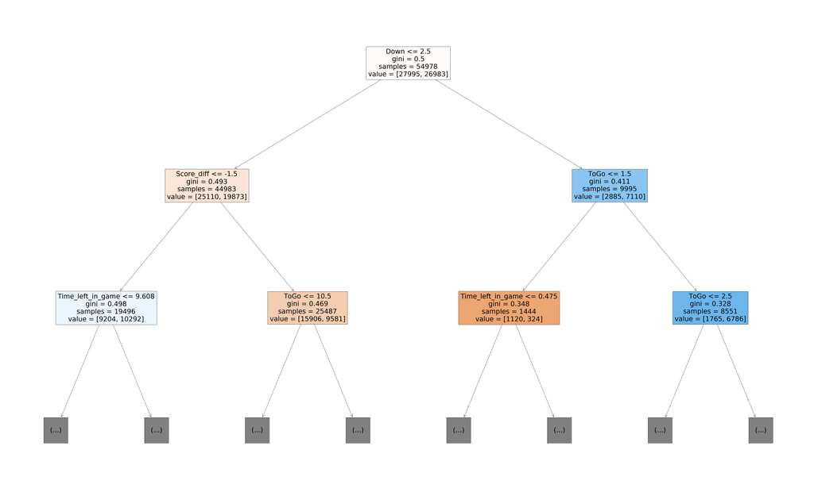

```python
rcParams['figure.figsize'] = 80,50

plot_tree(tree, filled = 'true', max_depth = 2, feature_names=X_train.columns)

plt.show()
```

So the most first split is created off of whether a play is coming on 1st/2nd down or on 3rd down. Makes sense!

Decision Trees are great but there are even better tree based algorithms. Lets see if we can get an increase from either a Random Forest Ensemble model or an XGBoost tree model.

### Random Forest

Random forests are simply an extension of decision trees where multiple trees are created and each tree is fit on a bootstrapped sample of the training data. The results of each tree are then combined into one final score which is the output of this model type. These model types are not as easy to read as decision trees though since there are many trees to look through.

Decision trees begin having hyperparameters that we will need to tune in order to get the best results. I will do only minimal tuning here; focusing on the n_estimators and max_depth parameters.

First a quick tune of n_estimators.

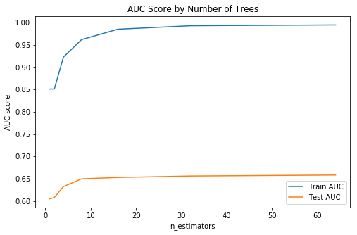

```python
rcParams['figure.figsize'] = 8,5
n_estimators = [1, 2, 4, 8, 16, 32, 64]
train_results = []
test_results = []
for estimator in n_estimators:
   rf = RandomForestClassifier(n_estimators=estimator, n_jobs=-1)
   rf.fit(X_train, y_train)
   train_pred = rf.predict(X_train)
   false_positive_rate, true_positive_rate, thresholds = roc_curve(y_train, train_pred)
   roc_auc = auc(false_positive_rate, true_positive_rate)
   train_results.append(roc_auc)
   y_pred = rf.predict(X_test)
   false_positive_rate, true_positive_rate, thresholds = roc_curve(y_test, y_pred)
   roc_auc = auc(false_positive_rate, true_positive_rate)
   test_results.append(roc_auc)
sns.lineplot(n_estimators, train_results, label = 'Train AUC')
sns.lineplot(n_estimators, test_results, label = 'Test AUC')
plt.ylabel('AUC score')
plt.xlabel('n_estimators')
plt.title('AUC Score by Number of Trees')
plt.show()
```

The large difference in training and testing scores is something to keep in mind going forward since it indicates this model as is is overfit. We can help reduce the Variance by adjusting other hyper parameters. This does show us that a 32 estimators should be sufficient for this task however.

Next we will attempt to address the high variance by adjusting the max depth. This controls how many levels are allowed in each tree. By default, no max depth is set and trees are built until each node is pure. This often leads to the overfitting as seen above.

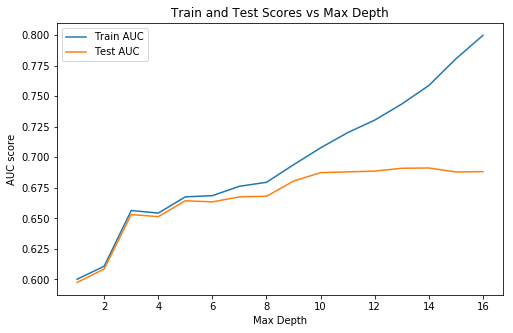

```python
max_depths = range(1, 17)
train_results = []
test_results = []
for max_depth in max_depths:
   rf = RandomForestClassifier(n_estimators=32, max_depth=max_depth, n_jobs=-1)
   rf.fit(X_train, y_train)
   train_pred = rf.predict(X_train)
   false_positive_rate, true_positive_rate, thresholds = roc_curve(y_train, train_pred)
   roc_auc = auc(false_positive_rate, true_positive_rate)
   train_results.append(roc_auc)
   y_pred = rf.predict(X_test)
   false_positive_rate, true_positive_rate, thresholds = roc_curve(y_test, y_pred)
   roc_auc = auc(false_positive_rate, true_positive_rate)
   test_results.append(roc_auc)
from matplotlib.legend_handler import HandlerLine2D
sns.lineplot(max_depths, train_results, label = 'Train AUC')
sns.lineplot(max_depths, test_results, label = 'Test AUC')
plt.ylabel('AUC score')
plt.xlabel('Max Depth')
plt.title('Train and Test Scores vs Max Depth')
plt.show()
```

That's as much parameter tuning as I want to do here though it is often advisable to tune the criterion and min_samples_split parameters as well. For now lets create our final random forest model using 32 estimators and a max depth of 11 and see what that gets us.

```python
rfc = RandomForestClassifier(n_estimators=32, max_depth=11)
rfc.fit(X_train, y_train)
train_preds = rfc.predict(X_train)
train_acc = accuracy_score(y_train, train_preds)
y_pred = rfc.predict(X_test)
test_acc = accuracy_score(y_test, y_pred)
print(f'Accuracy: {round(test_acc * 100,2)}%')
```

```
Accuracy: 68.98%
```

## Extreme Gradient Boosted Trees

Extreme Gradient Boosted Tree (XGBoost) algorithms are an extension of gradient boosted machines which fit sequential decision trees on the residuals of all previous trees. These algorithms can be quite complex and require more extensive parameter tuning but are state of the art when it comes to creating accurate predictions. For a gentle introduction to XGBoost algorithms, [see this article.](https://machinelearningmastery.com/gentle-introduction-xgboost-applied-machine-learning/)

So lets begin training our XGBoost algorithm.

In this effort, we will want to train a number of parameters, starting similarly to the random forest model with n_estimators. XGBoost allows for early stopping however which will help us train this parameter.

```
Accuracy: 69.33%
```

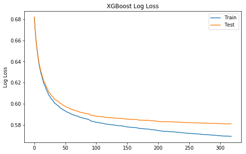

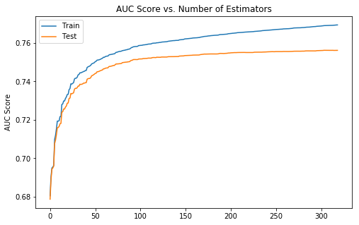

```python
# fit model to training data using Early Stopping
xgb = XGBClassifier(n_estimators=5000)
eval_set = [(X_train, y_train), (X_test, y_test)]
xgb.fit(X_train, y_train, eval_metric=["logloss", "auc"], eval_set=eval_set, verbose=False, early_stopping_rounds = 15)

# make predictions for test data
y_pred = xgb.predict(X_test)
predictions = [round(value) for value in y_pred]

# evaluate predictions
accuracy = accuracy_score(y_test, predictions)
print("Accuracy: %.2f%%" % (accuracy * 100.0))

# retrieve performance metrics
results = xgb.evals_result()
epochs = len(results['validation_0']['auc'])
x_axis = range(0, epochs)

# plot log loss
fig, ax = plt.subplots()
ax.plot(x_axis, results['validation_0']['logloss'], label='Train')
ax.plot(x_axis, results['validation_1']['logloss'], label='Test')
ax.legend()
plt.ylabel('Log Loss')
plt.title('XGBoost Log Loss')
plt.show()

# plot AUC
fig, ax = plt.subplots()
ax.plot(x_axis, results['validation_0']['auc'], label='Train')
ax.plot(x_axis, results['validation_1']['auc'], label='Test')
ax.legend()
plt.ylabel('AUC Score')
plt.title('AUC Score vs. Number of Estimators')
plt.show()
```

```python
print(f'Best n_estimator by Early Stopping: {xgb.best_ntree_limit}')
```

```
Best n_estimator by Early Stopping: 305
```

Now that we know we want to use 305 estimators, we will want to tune max_depth and min_child_weight first as those will result in the largest increase in score. To do this, we will use sklearn's GridSearchCV function. Additionaly, since we are using cross validation, we can use the entire dataset instead of splitting into train and test.

```python
param_test = {
 'max_depth':range(3,10),
 'min_child_weight':range(1,6)
}

xgb = XGBClassifier(n_estimators=305,
                    objective= 'binary:logistic', nthread=-1, seed=42)


gsearch1 = GridSearchCV(estimator = xgb,
                        param_grid = param_test,
                        scoring='accuracy',
                        n_jobs=16,
                        iid=False,
                        cv=5,
                        verbose = 1)
gsearch1.fit(X, y)
print(f'Best Parameters :{gsearch1.best_params_}\n\nBest Accuracy Score: {gsearch1.best_score_}')
```

```
Fitting 5 folds for each of 35 candidates, totalling 175 fits
```

```
[Parallel(n_jobs=16)]: Using backend LokyBackend with 16 concurrent workers.
[Parallel(n_jobs=16)]: Done  18 tasks      | elapsed:  1.0min
[Parallel(n_jobs=16)]: Done 175 out of 175 | elapsed:  6.9min finished
```

[output not shown]

```python
param_test = {
    'gamma': np.arange(0, .6, .1)
}

xgb = XGBClassifier(n_estimators=305,
                    max_depth = 4,
                    min_child_weight = 4,
                    objective= 'binary:logistic', nthread=-1, seed=42)


gsearch1 = GridSearchCV(estimator = xgb,
                        param_grid = param_test,
                        scoring='accuracy',
                        n_jobs=16,
                        iid=False,
                        cv=5,
                        verbose = 1)
gsearch1.fit(X, y)
print(f'Best Parameters :{gsearch1.best_params_}\n\nBest Accuracy Score: {gsearch1.best_score_}')
```

```
Fitting 5 folds for each of 6 candidates, totalling 30 fits
```

```
[Parallel(n_jobs=16)]: Using backend LokyBackend with 16 concurrent workers.
[Parallel(n_jobs=16)]: Done  30 out of  30 | elapsed:   51.2s remaining:    0.0s
[Parallel(n_jobs=16)]: Done  30 out of  30 | elapsed:   51.2s finished
```

```
Best Parameters :{'gamma': 0.30000000000000004}

Best Accuracy Score: 0.6961623956343295
```

We see that the original gamma of 0.3 is returned as the optimum score. Lets quickly check gamma values between 0.25 and .35 to see if any amount of gamma might be better than zero.

```python
param_test = {
    'gamma': np.arange(0.25, 0.36, .01)
}

xgb = XGBClassifier(n_estimators=305,
                    max_depth = 4,
                    min_child_weight = 4,
                    objective= 'binary:logistic', nthread=-1, seed=42)


gsearch1 = GridSearchCV(estimator = xgb,
                        param_grid = param_test,
                        scoring='accuracy',
                        n_jobs=16,
                        iid=False,
                        cv=5,
                        verbose = 1)
gsearch1.fit(X, y)
print(f'Best Parameters :{gsearch1.best_params_}\n\nBest Accuracy Score: {gsearch1.best_score_}')
```

```
Fitting 5 folds for each of 11 candidates, totalling 55 fits
```

```
[Parallel(n_jobs=16)]: Using backend LokyBackend with 16 concurrent workers.
[Parallel(n_jobs=16)]: Done  18 tasks      | elapsed:   40.4s
[Parallel(n_jobs=16)]: Done  55 out of  55 | elapsed:  1.4min finished
```

```
Best Parameters :{'gamma': 0.3500000000000001}

Best Accuracy Score: 0.6963573741750364
```

So we see a gamma of .35 provides a small amount of lift. We could continue pursuing this value but lets move on.

At this point it is good to re-calibrate the number of estimators using our new parameters before tuning our sampling values. So lets re-run the code from before with our new found parameters and see what we get.

```
Accuracy: 69.57%
```

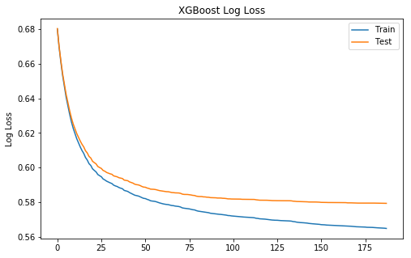

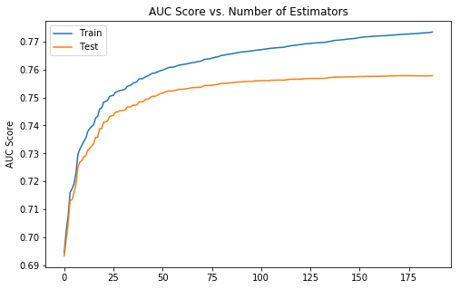

```python
# fit model to training data using Early Stopping
xgb = XGBClassifier(max_depth = 4,
                    min_child_weight = 4,
                    gamma = .35,
                    n_estimators=5000)
eval_set = [(X_train, y_train), (X_test, y_test)]
xgb.fit(X_train, y_train, eval_metric=["logloss", "auc"], eval_set=eval_set, verbose=False, early_stopping_rounds = 15)

# make predictions for test data
y_pred = xgb.predict(X_test)
predictions = [round(value) for value in y_pred]

# evaluate predictions
accuracy = accuracy_score(y_test, predictions)
print("Accuracy: %.2f%%" % (accuracy * 100.0))

# retrieve performance metrics
results = xgb.evals_result()
epochs = len(results['validation_0']['auc'])
x_axis = range(0, epochs)

# plot log loss
fig, ax = plt.subplots()
ax.plot(x_axis, results['validation_0']['logloss'], label='Train')
ax.plot(x_axis, results['validation_1']['logloss'], label='Test')
ax.legend()
plt.ylabel('Log Loss')
plt.title('XGBoost Log Loss')
plt.show()

# plot AUC
fig, ax = plt.subplots()
ax.plot(x_axis, results['validation_0']['auc'], label='Train')
ax.plot(x_axis, results['validation_1']['auc'], label='Test')
ax.legend()
plt.ylabel('AUC Score')
plt.title('AUC Score vs. Number of Estimators')
plt.show()
```

```python
print(f'Best n_estimator by Early Stopping: {xgb.best_ntree_limit}')
```

```
Best n_estimator by Early Stopping: 174
```

So now we see that we can stop training at 174 estimators. Next we can adjust the sampling parameters.

```python
param_test = {
    'subsample': np.arange(.7, .95, .05),
    'colsample_bytree': np.arange(.7, .95, .05)
}

xgb = XGBClassifier(n_estimators=174,
                    max_depth = 4,
                    min_child_weight = 4,
                    gamma = .35,
                    objective= 'binary:logistic', nthread=-1, seed=42)


gsearch1 = GridSearchCV(estimator = xgb,
                        param_grid = param_test,
                        scoring='accuracy',
                        n_jobs=16,
                        iid=False,
                        cv=5,
                        verbose = 1)
gsearch1.fit(X, y)
print(f'Best Parameters :{gsearch1.best_params_}\n\nBest Accuracy Score: {gsearch1.best_score_}')
```

```
Fitting 5 folds for each of 25 candidates, totalling 125 fits
```

```
[Parallel(n_jobs=16)]: Using backend LokyBackend with 16 concurrent workers.
[Parallel(n_jobs=16)]: Done  18 tasks      | elapsed:   21.2s
[Parallel(n_jobs=16)]: Done 125 out of 125 | elapsed:  1.8min finished
```

```
Best Parameters :{'colsample_bytree': 0.8500000000000001, 'subsample': 0.8}

Best Accuracy Score: 0.6952849836604041
```

We have found a colsample_bytree of .85 and a subsample of .8. We could drill down on this values further but we will leave these here.

The last parameters to tune are the regularization parameters: alpha and lambda.

```python
param_test = {
    'reg_alpha':[0, .5, 1],
    'reg_lambda':[1, 1.5, 2, 3, 4.5]
}

xgb = XGBClassifier(n_estimators=174,
                    max_depth = 4,
                    min_child_weight = 4,
                    gamma = .35,
                    subsample = .8,
                    colsample_bytree = .85,
                    objective= 'binary:logistic', nthread=-1, seed=42)


gsearch1 = GridSearchCV(estimator = xgb,
                        param_grid = param_test,
                        scoring='accuracy',
                        n_jobs=16,
                        iid=False,
                        cv=5,
                        verbose = 1)
gsearch1.fit(X, y)
print(f'Best Parameters :{gsearch1.best_params_}\n\nBest Accuracy Score: {gsearch1.best_score_}')
```

```
Fitting 5 folds for each of 15 candidates, totalling 75 fits
```

```
[Parallel(n_jobs=16)]: Using backend LokyBackend with 16 concurrent workers.
[Parallel(n_jobs=16)]: Done  18 tasks      | elapsed:   23.6s
[Parallel(n_jobs=16)]: Done  75 out of  75 | elapsed:  1.2min finished
```

```
Best Parameters :{'reg_alpha': 0.5, 'reg_lambda': 4.5}

Best Accuracy Score: 0.6956505809551425
```

We have some additional lift by setting alpha to .5 and lambda at 4.5. We used a fairly broad range of values so lets drill down just a little bit.

```python
param_test = {
    'reg_alpha': np.arange(.2, .8, .1),
    'reg_lambda': np.arange(4, 5.25, .25)
}

xgb = XGBClassifier(n_estimators=174,
                    max_depth = 4,
                    min_child_weight = 4,
                    gamma = .35,
                    subsample = .8,
                    colsample_bytree = .85,
                    objective= 'binary:logistic', nthread=-1, seed=42)


gsearch1 = GridSearchCV(estimator = xgb,
                        param_grid = param_test,
                        scoring='accuracy',
                        n_jobs=16,
                        iid=False,
                        cv=5,
                        verbose = 1)
gsearch1.fit(X, y)
print(f'Best Parameters :{gsearch1.best_params_}\n\nBest Accuracy Score: {gsearch1.best_score_}')
```

```
Fitting 5 folds for each of 35 candidates, totalling 175 fits
```

```
[Parallel(n_jobs=16)]: Using backend LokyBackend with 16 concurrent workers.
[Parallel(n_jobs=16)]: Done  18 tasks      | elapsed:   23.3s
[Parallel(n_jobs=16)]: Done 175 out of 175 | elapsed:  2.7min finished
```

```
Best Parameters :{'reg_alpha': 0.7000000000000002, 'reg_lambda': 4.0}

Best Accuracy Score: 0.6957358873632629
```

So now we have an alpha of .7 and lambda of 4. We could continue training these values but we will leave them there.

The last thing we want to do is to reduce the learning rate and use early stopping to find our final parameters. The default learning rate is 0.3, so we will lower it to 0.1.

We can use a small loop to find the optimum learning rate.

```python
learning_rates = [0.0001, 0.001, 0.01, 0.1, 0.2, 0.3]

for learning_rate in learning_rates:
    # fit model to training data using Early Stopping
    xgb = XGBClassifier(max_depth = 4,
                        min_child_weight = 4,
                        gamma = .35,
                        subsample = .8,
                        colsample_bytree = .85,
                        reg_alpha = .7,
                        reg_lambda = 4,
                        learning_rate = learning_rate,
                        n_estimators=5000,
                        n_jobs = 16)
    eval_set = [(X_train, y_train), (X_test, y_test)]
    xgb.fit(X_train, y_train, eval_metric=["logloss", "auc"], eval_set=eval_set,
            verbose=False, early_stopping_rounds = 50)

    # make predictions for test data
    y_pred = xgb.predict(X_test)
    predictions = [round(value) for value in y_pred]

    # evaluate predictions
    accuracy = accuracy_score(y_test, predictions)
    print(f"Learning Rate: {learning_rate} Estimators: {xgb.best_ntree_limit} Accuracy: {accuracy * 100.0}%\n " )
```

```
Learning Rate: 0.0001 Estimators: 29 Accuracy: 66.01056168987039%

Learning Rate: 0.001 Estimators: 30 Accuracy: 66.02533328409469%

Learning Rate: 0.01 Estimators: 2415 Accuracy: 69.68499575316666%

Learning Rate: 0.1 Estimators: 341 Accuracy: 69.59267328926474%

Learning Rate: 0.2 Estimators: 148 Accuracy: 69.74408213006389%

Learning Rate: 0.3 Estimators: 154 Accuracy: 69.4745005354703%
```

We are actually seeing a slightly better accuracy by raising the learning rate a bit. Lets play around with these numbers a little more.

```python
learning_rates = np.arange(.1, .3, .01)

for learning_rate in learning_rates:
    # fit model to training data using Early Stopping
    xgb = XGBClassifier(max_depth = 4,
                        min_child_weight = 4,
                        gamma = .35,
                        subsample = .8,
                        colsample_bytree = .85,
                        reg_alpha = .7,
                        reg_lambda = 4,
                        learning_rate = learning_rate,
                        n_estimators=5000,
                        n_jobs = 16)
    eval_set = [(X_train, y_train), (X_test, y_test)]
    xgb.fit(X_train, y_train, eval_metric=["logloss", "auc"], eval_set=eval_set,
            verbose=False, early_stopping_rounds = 50)

    # make predictions for test data
    y_pred = xgb.predict(X_test)
    predictions = [round(value) for value in y_pred]

    # evaluate predictions
    accuracy = accuracy_score(y_test, predictions)
    print(f"Learning Rate: {learning_rate} Estimators: {xgb.best_ntree_limit} Accuracy: {accuracy * 100.0}% " )
```

```
Learning Rate: 0.1 Estimators: 341 Accuracy: 69.59267328926474%
Learning Rate: 0.11 Estimators: 303 Accuracy: 69.80316850696111%
Learning Rate: 0.12 Estimators: 368 Accuracy: 69.67391705749844%
Learning Rate: 0.13 Estimators: 204 Accuracy: 69.60744488348905%
Learning Rate: 0.13999999999999999 Estimators: 303 Accuracy: 69.73300343439566%
Learning Rate: 0.14999999999999997 Estimators: 158 Accuracy: 69.7588537242882%
Learning Rate: 0.15999999999999998 Estimators: 228 Accuracy: 69.67391705749844%
Learning Rate: 0.16999999999999998 Estimators: 231 Accuracy: 69.70346024594704%
Learning Rate: 0.17999999999999997 Estimators: 240 Accuracy: 69.67022415894235%
Learning Rate: 0.18999999999999995 Estimators: 183 Accuracy: 69.61852357915728%
Learning Rate: 0.19999999999999996 Estimators: 148 Accuracy: 69.74408213006389%
Learning Rate: 0.20999999999999996 Estimators: 165 Accuracy: 69.68499575316666%
Learning Rate: 0.21999999999999995 Estimators: 124 Accuracy: 69.65545256471805%
Learning Rate: 0.22999999999999995 Estimators: 177 Accuracy: 69.52989401381144%
Learning Rate: 0.23999999999999994 Estimators: 85 Accuracy: 69.45972894124598%
Learning Rate: 0.24999999999999992 Estimators: 107 Accuracy: 69.55574430370397%
Learning Rate: 0.2599999999999999 Estimators: 114 Accuracy: 69.4745005354703%
Learning Rate: 0.2699999999999999 Estimators: 113 Accuracy: 69.52250821669928%
Learning Rate: 0.2799999999999999 Estimators: 141 Accuracy: 69.68499575316666%
Learning Rate: 0.2899999999999999 Estimators: 107 Accuracy: 69.66283836183021%
```

Looks like a learning rate of 0.11 with 303 estimators is going to give our best results. With an accuracy of just under 70%! This is an excellent lift from the original logistic regression accuracy of 63.7 and even better from the naive guess of 50.8%.

With all the parameters finalized, we can train our final model! We will use the parameters identified to build the final model on the entire dataset and save it to disk for use later.

```python
XGB_Run_Pass_Final = XGBClassifier(max_depth = 4,
                        min_child_weight = 4,
                        gamma = .35,
                        subsample = .8,
                        colsample_bytree = .85,
                        reg_alpha = .7,
                        reg_lambda = 4,
                        learning_rate = .11,
                        n_estimators=303,
                        n_jobs = 16)

XGB_Run_Pass_Final.fit(X, y)
```

```
XGBClassifier(base_score=0.5, booster='gbtree', colsample_bylevel=1,
              colsample_bynode=1, colsample_bytree=0.85, gamma=0.35,
              learning_rate=0.11, max_delta_step=0, max_depth=4,
              min_child_weight=4, missing=None, n_estimators=303, n_jobs=16,
              nthread=None, objective='binary:logistic', random_state=0,
              reg_alpha=0.7, reg_lambda=4, scale_pos_weight=1, seed=None,
              silent=None, subsample=0.8, verbosity=1)
```

One thing you may want to do is to keep an eye on what features are driving your predictions, so lets quickly show the feature importance plot for this final model.

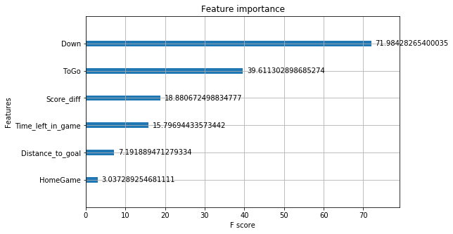

```python
from xgboost import plot_importance
plot_importance(XGB_Run_Pass_Final, importance_type='gain' )
plt.show()
```

As expected, Down and Distance are the two most important factors in deciding to run or pass. Home vs Away games have some influece but is the least impactful variable in our model.

With everything finalized, lets save this model for later.

```python
import pickle
pickle.dump(XGB_Run_Pass_Final, open("Models/Run_Pass_XGB.pkl", "wb"))
```

## Conclusions

So after everything is said and done, we have created an XGBoost model to predict whether a team will be running or passing on their next play that is correct 70% of the time! While I'm satisfied with this model for now, I believe that adding in additional information to the model such as offensive and defensive rankings, weather, and potentially even previous play success rates could result in an even greater model. We could also attempt some deep learning models to see if that helps but that is beyond the scope of what I want to do here.

Thank you for following along on this model creation and let me know if you'd like to see more like this.

## EDIT:

I have now wrapped this model in an app and deployed it to the web. If you would like to play with this model and create your own prediction just visit http://nfl-play-prediction-app.herokuapp.com/

Fair warning, I am not a web developer so it isn't the prettiest but all the functionality is there. Also if the app hasn't been used in a while it may take a few seconds to wake up.